# Experiment 3 Pypool Preprocessing

Dave Braun

7/24/2019

*This document was last updated at 2022-05-03 16:32:44.*

This document is dedicated to preprocessing the data from Experiment 3.

Import and view the data:

```r
dst <- read.csv('../../data/dst.csv')
demo <- read.csv('../../data/demo.csv')
rapidFire <- read.csv('../../data/rapidFire.csv')
pracCued <- read.csv('../../data/pracCued.csv')

n <- nrow(demo)

head(pracCued)
```

|  | subject | survey_code | curTime | userAgent | screenWidth | screenHeight | windowWidth | windowHeight | phase | blueTask | redTask | cuedRunTime | trialCount | rsi | runTimeMins | stimulus | stimColor | taskCode | responseKey | transition | error | rt |
| --- | --- | --- | --- | --- | --- | --- | --- | --- | --- | --- | --- | --- | --- | --- | --- | --- | --- | --- | --- | --- | --- | --- |
| 1 | a0235_oooku3eys9 | 13146 | 19/11/2021@22:02:27 | Mozilla/5.0 (Macintosh; Intel Mac OS X 10_15_7) AppleWebKit/537.36 (KHTML, like Gecko) Chrome/95.0.4638.69 Safari/537.36 | 1440 | 900 | 1391 | 696 | pracCued | par | mag | 85548072 | 1 | 200 | 1421 | 2 | blue | par | j | startBlock | 1 | 13114 |
| 2 | a0235_oooku3eys9 | 13146 | 19/11/2021@22:02:27 | Mozilla/5.0 (Macintosh; Intel Mac OS X 10_15_7) AppleWebKit/537.36 (KHTML, like Gecko) Chrome/95.0.4638.69 Safari/537.36 | 1440 | 900 | 1391 | 696 | pracCued | par | mag | 85548072 | 2 | 200 | 1421 | 8 | red | mag | j | switch | 1 | 3258 |
| 3 | a0235_oooku3eys9 | 13146 | 19/11/2021@22:02:27 | Mozilla/5.0 (Macintosh; Intel Mac OS X 10_15_7) AppleWebKit/537.36 (KHTML, like Gecko) Chrome/95.0.4638.69 Safari/537.36 | 1440 | 900 | 1391 | 696 | pracCued | par | mag | 85548072 | 3 | 200 | 1421 | 6 | red | mag | k | repeat | 0 | 1394 |
| 4 | a0235_oooku3eys9 | 13146 | 19/11/2021@22:02:27 | Mozilla/5.0 (Macintosh; Intel Mac OS X 10_15_7) AppleWebKit/537.36 (KHTML, like Gecko) Chrome/95.0.4638.69 Safari/537.36 | 1440 | 900 | 1391 | 696 | pracCued | par | mag | 85548072 | 4 | 200 | 1421 | 9 | blue | par | k | switch | 1 | 1682 |
| 5 | a0235_oooku3eys9 | 13146 | 19/11/2021@22:02:27 | Mozilla/5.0 (Macintosh; Intel Mac OS X 10_15_7) AppleWebKit/537.36 (KHTML, like Gecko) Chrome/95.0.4638.69 Safari/537.36 | 1440 | 900 | 1391 | 696 | pracCued | par | mag | 85548072 | 5 | 200 | 1421 | 3 | blue | par | j | repeat | 0 | 6104 |
| 6 | a0235_oooku3eys9 | 13146 | 19/11/2021@22:02:27 | Mozilla/5.0 (Macintosh; Intel Mac OS X 10_15_7) AppleWebKit/537.36 (KHTML, like Gecko) Chrome/95.0.4638.69 Safari/537.36 | 1440 | 900 | 1391 | 696 | pracCued | par | mag | 85548072 | 6 | 200 | 1422 | 4 | red | mag | k | switch | 1 | 6232 |

```r
N_analyzed <- length(unique(dst[dst$corrected_effort_units=='false',]$subject))
```

**The initial sample size is 262.**

**The initial sample size for only those in the uncorrected condition (which is what is being reported as E2B in the ms) is 111.**

## Run time

For piloting purposes, I’m curious as to how long the experiment is running.  
So far in piloting, I’ve implemented two different versions: one where there were 8 total cycles in DST and one with 10.

```r
dstTrim <- dst %>%
  group_by(subject) %>%
  summarize(dstRunTimeMins = max(phaseRunTimeMins),
            cycleThreshold = max(choiceTrial))

rapidFireTrim <- rapidFire %>%
  group_by(subject) %>%
  summarize(rapidFireRunTimeMins = max(phaseRunTimeMins))

pracCuedTrim <- pracCued %>%
  group_by(subject) %>%
  summarize(pracCuedRunTimeMins = max(runTimeMins))

demoTrim <- demo %>%
  select(subject, totalTime_mins)

d <- dstTrim %>%
  inner_join(rapidFireTrim) %>%
  inner_join(pracCuedTrim) %>%
  inner_join(demoTrim)
d
```

| subject | dstRunTimeMins | cycleThreshold | rapidFireRunTimeMins | pracCuedRunTimeMins | totalTime_mins |
| --- | --- | --- | --- | --- | --- |
| a0235_oooku3eys9 | 22 | 40 | 1 | 1426 | 1451 |
| a1926_qj0x93avxqc | 24 | 40 | 1 | 6 | 32 |
| a40919_fsdw2ik852v | 19 | 40 | 2 | 6 | 28 |
| a4165_q1a9gul2j9b | 25 | 40 | 3 | 54 | 83 |
| a41823_ahl091r6rks | 34 | 40 | 2 | 8 | 49 |
| a43011_a73kv74rkup | 20 | 40 | 1 | 8 | 29 |
| a5561_xveqah9tfk | 23 | 40 | 2 | 8 | 33 |
| a6316_mznm33broy | 25 | 40 | 2 | 7 | 35 |
| a6325_j1aszi2m35 | 14 | 40 | 1 | 5 | 27 |
| a857_4lq67w46n2q | 129 | 40 | 1 | 6 | 137 |

[output cut: 247 more lines]

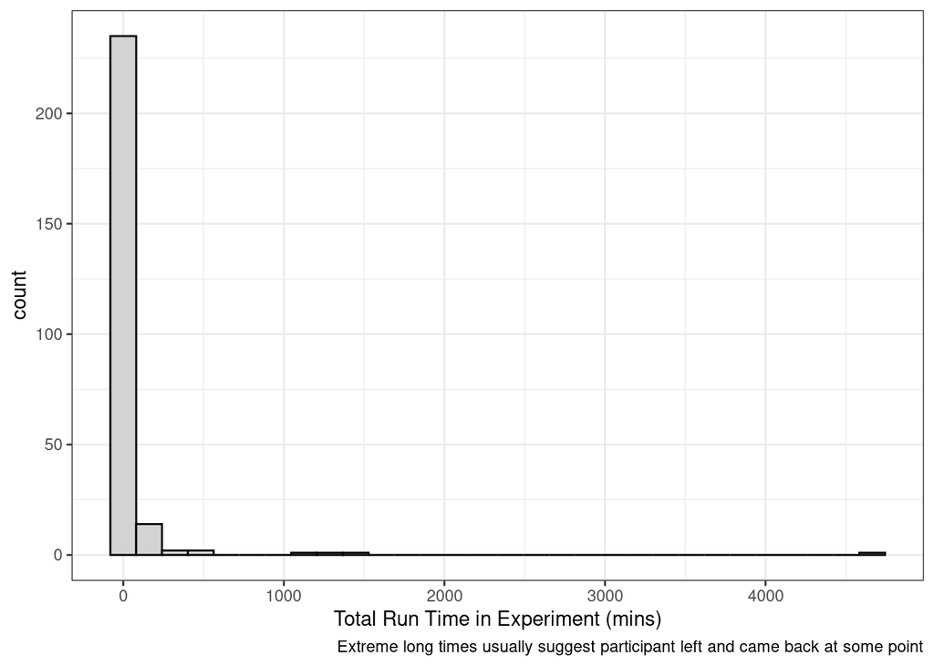

```r
d %>%
  ggplot(aes(x = totalTime_mins)) +
  geom_histogram(color = 'black', fill = 'light grey') +
  labs(
    x = 'Total Run Time in Experiment (mins)',
    caption = 'Extreme long times usually suggest participant left and came back at some point'
  ) +
  theme_bw()
```

## Subject Exclusion

Subjects will be excluded for:

- Not having normal or corrected-to-normal vision
- Having error rates higher than 15%

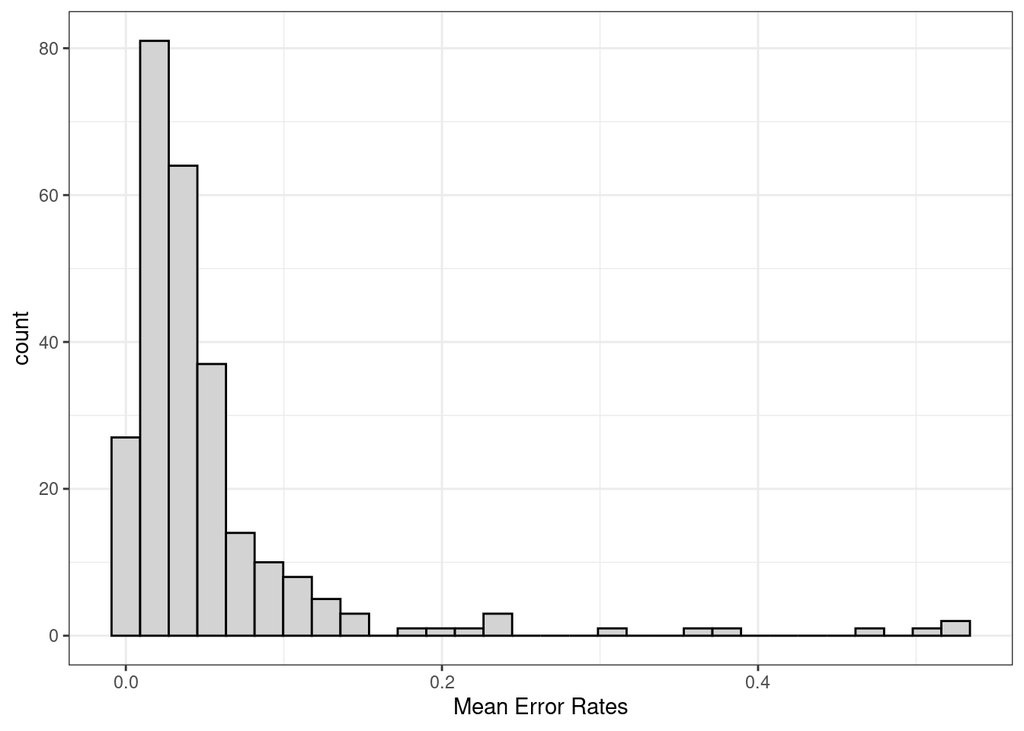

```r
badSubjectsList <- demo[demo$vision == 'impaired',]$subject
badSubjects <- data.frame(subject = badSubjectsList, reason = rep('Vision impaired', length(badSubjectsList)))

badSubjectsList <- dst %>%
  group_by(subject) %>%
  summarize(error = mean(error))

badSubjectsList %>%
  ggplot(aes(x = error)) +
  geom_histogram(color = 'black', fill = 'light grey', bins = ifelse(n < 10, 10, 30)) +
  theme_bw() +
  xlab('Mean Error Rates')
```

```r
badSubjectsList <- badSubjectsList[badSubjectsList$error > .15,]$subject
badSubjects <- rbind(badSubjects, data.frame(subject = badSubjectsList, reason = rep('Error rate higher than 15%', length(badSubjectsList))))
write.csv(badSubjects, '../../data/badSubjects.csv', row.names = FALSE)
badSubjects
```

| subject | reason |
| --- | --- |
| a%252525604410_svizw33gfu | Vision impaired |
| a1926_qj0x93avxqc | Vision impaired |
| b0825_oak32q9nm3o | Vision impaired |
| f7811_cu4vlhsfz5 | Vision impaired |
| k71831_4rcrkvgkav3 | Vision impaired |
| l847_jrzcm5ayg1h | Vision impaired |
| m2102_e0t9x7ryb0l | Vision impaired |
| n3202_1z96jehjrwr | Vision impaired |
| r727_9c6m9q40o2k | Vision impaired |
| s51223_eahxasoay1 | Vision impaired |

[output cut: 17 more lines]

```r
good <- dst %>%
  filter(cuedRt < 10000) %>%
  group_by(subject) %>%
  summarize(error = mean(error), rt = mean(cuedRt)) %>%
  filter(error < .35)

bad <- dst %>%
  filter(cuedRt < 10000) %>%
  group_by(subject) %>%
  summarize(error = mean(error), rt = mean(cuedRt)) %>%
  filter(error > .35)
```

```r
good
```

| subject | error | rt |
| --- | --- | --- |
| a%25604410_svizw33gfu | 0.004411765 | 1225.2029 |
| a0235_oooku3eys9 | 0.029498525 | 1191.6991 |
| a1926_qj0x93avxqc | 0.098529412 | 1108.9235 |
| a40919_fsdw2ik852v | 0.066176471 | 1147.1956 |
| a4165_q1a9gul2j9b | 0.013235294 | 1325.4926 |
| a41823_ahl091r6rks | 0.099259259 | 1255.0548 |
| a43011_a73kv74rkup | 0.036873156 | 1142.4882 |
| a5561_xveqah9tfk | 0.033823529 | 1130.6632 |
| a6316_mznm33broy | 0.008836524 | 1408.8513 |
| a857_4lq67w46n2q | 0.027941176 | 970.2544 |

[output cut: 246 more lines]

```r
bad
```

| subject | error | rt |
| --- | --- | --- |
| a6325_j1aszi2m35 | 0.5036819 | 383.1384 |
| b0106_gjqgnwa10xs | 0.5205882 | 178.9412 |
| d4312_ij0zpb3v6hh | 0.5254491 | 1999.3533 |
| h3820_mblrjd0fru | 0.4676471 | 503.9794 |
| n3306_u4u13lapaic | 0.3558824 | 468.8647 |
| w2132_mcigv1wvafc | 0.3852941 | 356.9382 |

Plot the clustering of humans and bots (although, I don’t expect there to be many bots this time because I implemented something in the experiment to prevent them).

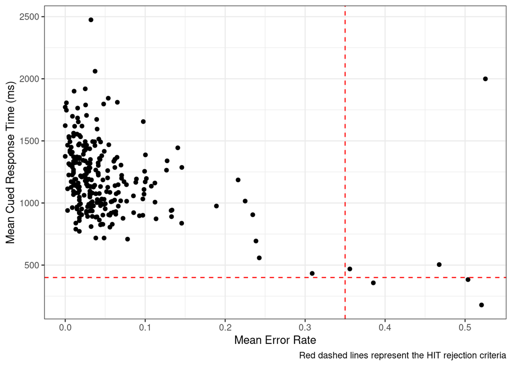

```r
rejectList <- read.csv('../identitiesAndRejections/rejectList.csv')

rejectList <- ifelse(nrow(rejectList) > 0, rejectList$subject, -99)

dst %>%
  filter(cuedRt < 10000) %>%
  group_by(subject) %>%
  summarize(error = mean(error), rt = mean(cuedRt)) %>%
  ggplot(aes(x = error, y = rt)) +
  geom_point() +
  xlab('Mean Error Rate') +
  ylab('Mean Cued Response Time (ms)') +
  labs(caption = 'Red dashed lines represent the HIT rejection criteria') +
  theme_bw() +
  theme(legend.position = 'bottom') +
  geom_vline(xintercept = 0.35, linetype = 'dashed', color = 'red') +
  geom_hline(yintercept = 400, linetype = 'dashed', color = 'red')
```

Drop bad data

```r
print(paste('Number of rows before dropping bad subjects:', nrow(dst)))
```

```
## [1] "Number of rows before dropping bad subjects: 178160"
```

```r
dst <- dst[!(dst$subject %in% badSubjects$subject),]
print(paste('Number of rows after dropping bad subjects:', nrow(dst)))
```

```
## [1] "Number of rows after dropping bad subjects: 160480"
```

```r
demo <- demo[!(demo$subject %in% badSubjects$subject),]
rapidFire <- rapidFire[!(rapidFire$subject %in% badSubjects$subject),]
```

Zoom in on error rates for everyone else:

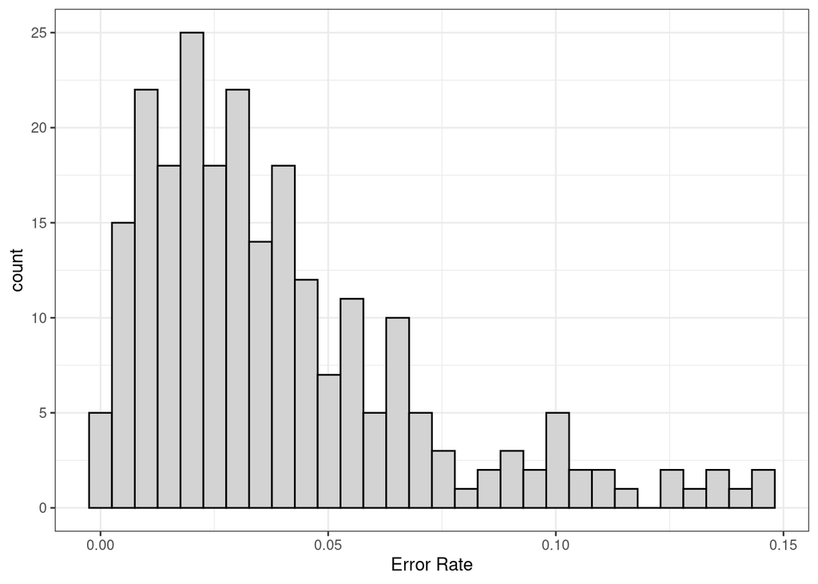

```r
dst %>%
  group_by(subject) %>%
  summarize(error = mean(error)) %>%
  ggplot(aes(x = error)) +
  geom_histogram(color = 'black', fill = 'light grey') +
  theme_bw() +
  xlab('Error Rate')
```

## Error and RT Trimming

I’m handling all trimming of performance data first, followed by choice data.

### Performance

First, dropping all trials with RT > 10 s

**The choice-trimming procedures used for the DST phase will also be applied to the rapid choice phase. Summaries below reflect only trimming to DST phase.**

```r
## keep only cued < 10 s
initialRows <- nrow(dst)

print(paste('Number of rows before removing trials with RTs longer than 10 s:', initialRows))
```

```
## [1] "Number of rows before removing trials with RTs longer than 10 s: 160480"
```

```r
dst <- dst %>%
  filter(cuedRt < 10000)

print(paste('Number of rows after removing trials with RTs longer than 10 s:', nrow(dst)))
```

```
## [1] "Number of rows after removing trials with RTs longer than 10 s: 159494"
```

```r
badTrials <- data.frame('Data Dropped' = round(1 - (nrow(dst) / initialRows), 4), Reason = 'Cued trials longer than 10 s')

badTrials
```

| Data.Dropped | Reason |
| --- | --- |
| 0.0061 | Cued trials longer than 10 s |

```r
## subject-wise cued rt trimming
initialRows <- nrow(dst)
print(paste('Number of rows before removing trials where cued responses exceeded participant-wise cued RT cutoffs:', initialRows))
```

```
## [1] "Number of rows before removing trials where cued responses exceeded participant-wise cued RT cutoffs: 159494"
```

```r
dst0 <- dst %>%
  group_by(subject) %>%
  summarize(meancuedRt = mean(cuedRt), sdcuedRt = sd(cuedRt)) %>%
  inner_join(dst) %>%
  mutate(badcued = ifelse(cuedRt <= meancuedRt - 2 * sdcuedRt | cuedRt > meancuedRt + 2 * sdcuedRt, 1, 0)) %>%
  filter(badcued == 0) %>%
  select(-badcued)
print(paste('Number of rows before removing trials where cued responses exceeded participant-wise cued RT cutoffs:', nrow(dst0)))
```

```
## [1] "Number of rows before removing trials where cued responses exceeded participant-wise cued RT cutoffs: 152096"
```

```r
badTrials <- rbind(badTrials, data.frame('Data Dropped' = round(1 - (nrow(dst0) / initialRows), 4), Reason = 'Cued trials with RTs more extreme than two SDs beyond participant-wise means'))
badTrials
```

| Data.Dropped | Reason |
| --- | --- |
| 0.0061 | Cued trials longer than 10 s |
| 0.0464 | Cued trials with RTs more extreme than two SDs beyond participant-wise means |

### Choice

Saving out multiple datasets, one with each different trimming criterion (ie, nothing vs trim 10 s and subject-wise)

```r
## choice first
## keep only < 10 s
initialRows <- nrow(dst0)
print(paste('Number of rows before removing trials where choices RTs exceeded 10 s', initialRows))
```

```
## [1] "Number of rows before removing trials where choices RTs exceeded 10 s 152096"
```

```r
dst1 <- dst0 %>%
  filter(choiceRt < 10000)
print(paste('Number of rows after removing trials where choices RTs exceeded 10 s', nrow(dst1)))
```

```
## [1] "Number of rows after removing trials where choices RTs exceeded 10 s 147608"
```

```r
badTrials <- rbind(badTrials, data.frame('Data Dropped' = round(1 - (nrow(dst1) / initialRows), 4), Reason = 'Choice trials with with RTs  > 10 s'))

print(paste('Number of rows before removing trials where choices exceeded participant-wise choice RT cutoffs:', initialRows))
```

```
## [1] "Number of rows before removing trials where choices exceeded participant-wise choice RT cutoffs: 152096"
```

```r
dst1 <- dst1 %>%
  group_by(subject) %>%
  summarize(meanChoiceRt = mean(choiceRt), sdChoiceRt = sd(choiceRt)) %>%
  inner_join(dst) %>%
  mutate(badChoice = ifelse(choiceRt <= meanChoiceRt - 2 * sdChoiceRt | choiceRt > meanChoiceRt + 2 * sdChoiceRt, 1, 0)) %>%
  filter(badChoice == 0) %>%
  select(-badChoice, meanChoiceRt, sdChoiceRt)
rapidFire <- rapidFire %>%
  group_by(subject) %>%
  summarize(meanChoiceRt = mean(choiceRt), sdChoiceRt = sd(choiceRt)) %>%
  inner_join(rapidFire) %>%
  mutate(badChoice = ifelse(choiceRt <= meanChoiceRt - 2 * sdChoiceRt | choiceRt > meanChoiceRt + 2 * sdChoiceRt, 1, 0)) %>%
  filter(badChoice == 0) %>%
  select(-badChoice, meanChoiceRt, sdChoiceRt)
print(paste('Number of rows after removing trials where choices exceeded participant-wise choice RT cutoffs:', nrow(dst1)))
```

```
## [1] "Number of rows after removing trials where choices exceeded participant-wise choice RT cutoffs: 146029"
```

```r
badTrials <- rbind(badTrials, data.frame('Data Dropped' = round(1 - (nrow(dst1) / initialRows), 2), Reason = 'Choice trials with RTs more extreme than two SDs beyond participant-wise means'))
badTrials
```

| Data.Dropped | Reason |
| --- | --- |
| 0.0061 | Cued trials longer than 10 s |
| 0.0464 | Cued trials with RTs more extreme than two SDs beyond participant-wise means |
| 0.0295 | Choice trials with with RTs > 10 s |
| 0.0400 | Choice trials with RTs more extreme than two SDs beyond participant-wise means |

Saving out a dataset for error analysis

```r
write.csv(dst, '../../data/dstCleanErrors.csv', row.names = FALSE)
```

Trimming out error trials and trials following error trials  
*I didn’t actually say I’d trim trials following error trials in the document, so I might want to think about that some*

```r
initialRows <- nrow(dst0)
print(paste('Number of rows before removing error trials and trials following error trials :', initialRows))
```

```
## [1] "Number of rows before removing error trials and trials following error trials : 152096"
```

```r
dst0 <- dst0 %>%
  mutate(errorTrim = ifelse(error | shift(error), 1, 0)) %>%
  filter(errorTrim == 0)

dst1 <- dst1 %>%
  mutate(errorTrim = ifelse(error | shift(error), 1, 0)) %>%
  filter(errorTrim == 0)

print(paste('Number of rows before removing error trials and trials following error trials :', nrow(dst0)))
```

```
## [1] "Number of rows before removing error trials and trials following error trials : 140603"
```

```r
badTrials <- rbind(badTrials, data.frame('Data Dropped' = round(1 - (nrow(dst0) / initialRows), 2), Reason = 'Trimming error trials and trials following error trials'))
badTrials
```

| Data.Dropped | Reason |
| --- | --- |
| 0.0061 | Cued trials longer than 10 s |
| 0.0464 | Cued trials with RTs more extreme than two SDs beyond participant-wise means |
| 0.0295 | Choice trials with with RTs > 10 s |
| 0.0400 | Choice trials with RTs more extreme than two SDs beyond participant-wise means |
| 0.0800 | Trimming error trials and trials following error trials |

That should be good.

```r
write.csv(dst0, '../../data/dstClean.csv', row.names = FALSE)
write.csv(demo, '../../data/demoClean.csv', row.names = FALSE)
write.csv(rapidFire, '../../data/rapidFireClean.csv', row.names = FALSE)

## save out condensed data with choices only

dst0 <- dst0 %>%
  group_by(subject, choiceTrial) %>%
  summarize(choiceRt = mean(choiceRt),
            chosenDeckId = unique(chosenDeckId),
            difference = unique(difference),
            difficulty = unique(difficulty),
            selectedDeckLocation = unique(selectedDeckLocation),
            leftDeckId = unique(leftDeckId),
            rightDeckId = unique(rightDeckId),
            riskyDeckSwitchTop = unique(riskyDeckSwitchTop),
            riskyDeckSwitchBottom = unique(riskyDeckSwitchBottom),
            safeDeckSwitch = unique(safeDeckSwitch),
            corrected_effort_units = unique(corrected_effort_units),
            outcomeSwitch = unique(outcomeSwitch),
            condition = unique(condition),
            selectedRiskyDeck = unique(selectedRiskyDeck)) %>%
  ungroup()
dst1 <- dst1 %>%
  group_by(subject, choiceTrial) %>%
  summarize(choiceRt = mean(choiceRt),
            chosenDeckId = unique(chosenDeckId),
            difference = unique(difference),
            difficulty = unique(difficulty),
            selectedDeckLocation = unique(selectedDeckLocation),
            leftDeckId = unique(leftDeckId),
            rightDeckId = unique(rightDeckId),
            riskyDeckSwitchTop = unique(riskyDeckSwitchTop),
            riskyDeckSwitchBottom = unique(riskyDeckSwitchBottom),
            safeDeckSwitch = unique(safeDeckSwitch),
            corrected_effort_units = unique(corrected_effort_units),
            outcomeSwitch = unique(outcomeSwitch),
            condition = unique(condition),
            selectedRiskyDeck = unique(selectedRiskyDeck)) %>%
  ungroup()
write.csv(dst0, '../../data/dstCleanChoice.csv', row.names = FALSE)

write.csv(dst1, '../../data/dstCleanChoice1.csv', row.names = FALSE)

n <- dst %>%
  group_by(subject) %>%
  summarize(n()) %>%
  nrow()
```

**Final sample size is 236.**

[Analysis Homepage](https://davebraun.net/dissertation/experiments/analysis/)

A work by [Dave Braun](https://davebraun.net)

*dab414@lehigh.edu*